[figure not shown]

## Student Name: Calvin

## Student ID: Lecture 01 live HTML reset code cells

# Lecture 01: Basics of R and Jupyter Notebooks

[figure not shown]

## 0.1.0 About Introduction to R

Introduction to R is brought to you by the **Centre for the Analysis of Genome Evolution & Function (CAGEF)** bioinformatics training initiative. This course was developed based on feedback on the needs and interests of the Department of Cell & Systems Biology and the Department of Ecology and Evolutionary Biology.

The structure of this course is a code-along style; It is 100% hands on! A few hours prior to each lecture, links to the materials will be available for download at [QUERCUS](https://q.utoronto.ca/). The teaching materials will consist of a Jupyter Notebook with concepts, comments, instructions, and blank coding spaces that you will fill out with R by coding along with the instructor. Other teaching materials include a live-updating HTML version of the notebook, and datasets to import into R - when required. This learning approach will allow you to spend the time coding and not taking notes!

As we go along, there will be some in-class challenge questions for you to solve either individually or in cooperation with your peers. Post lecture assessments will also be available (see syllabus for grading scheme and percentages of the final mark) through [DataCamp](https://Datacamp.com) to help cement and/or extend what you learn each week.

### 0.1.1 Where is this course headed?

We'll take a blank slate approach here to R and assume that you pretty much know *nothing* about programming. From the beginning of this course to the end, we want to take you from some potential scenarios such as...

- A pile of data (like an excel file or tab-separated file) full of experimental observations and you don't know what to do with it.
- Maybe you're manipulating large tables all in excel, making custom formulas and pivot tables with graphs. Now you have to repeat similar experiments and do the analysis again.
- You're generating high-throughput data and there aren't any bioinformaticians around to help you sort it out.
- You heard about R and what it *could* do for your data analysis but don't know what that means or where to start.

and get you to a point where you can...

- Format your data correctly for analysis
- Produce basic plots and perform exploratory analysis
- Make functions and scripts for re-analysing existing or new data sets
- Track your experiments in a digital notebook like Jupyter!

[figure not shown]

### 0.1.2 How do we get there? Step-by-step.

In the first lesson, we will talk about the basic data structures and objects in R, get cozy with the Jupyter Notebook environment, and learn how to get help when you are stuck because everyone gets stuck - a lot! Then you will learn how to get your data in and out of R, how to tidy our data (data wrangling), and then subset and merge data. After that, we will dig into the data and learn how to make basic plots for both exploratory data analysis and publication. We'll follow that up with data cleaning and string manipulation; this is really the battleground of coding - getting your data into just the right format where you can analyse it more easily. We'll then spend a lecture digging into the functions available for the statistical anlaysis of your data. Lastly, we will learn about control flow how to write customized functions, which can really save you time and help scale up your analyses.

[figure not shown]

Don't forget, the structure of the class is a **code-along** style: it is fully hands on. At the end of each lecture, the complete notes will be made available in a PDF format through the corresponding Quercus module so you don't have to spend your attention on taking notes.

### 0.1.3 What kind of coding style will we learn?

There is no single path correct from A to B - although some paths may be more elegant, or more efficient than others. With that in mind, the emphasis in this lecture series will be on:

1. **Code simplicity** - learn helpful functions that allow you to focus on understanding the basic tenets of good data wrangling (reformatting) to facilitate quick exploratory data analysis and visualization.
2. **Code readability** - format and comment your code for yourself and others so that even those with minimal experience in R will be able to quickly grasp the overall steps in your code.
3. **Code stability** - while the core R code is relatively stable, behaviours of functions can still change with updates. There are well-developed packages we'll focus on for our analyses. Namely, we'll become more familiar with the `tidyverse` series of packages. This resource is well-maintained by a large community of developers. While not always the "fastest" approach, this additional layer can help ensure your code still runs (somewhat) smoothly later down the road.

## 0.2.0 Class Objectives

This is the first in a series of seven lectures. At the end of this session you will be familiar with the Jupyter Notebook environment and the R-kernel associated with it. You will know about basic data structures in R and how to create them. You will be able to install and load packages. Our topics are broken into:

1. Familiarizing with Jupyter Notebooks, and the R-kernel.
2. Getting started with programming
3. Data types in R
4. Understanding the Factor data type!

These concepts are necessary for coding best practices and to understand your data types for analysis.

[figure not shown]

## 0.3.0 A legend for text format in Jupyter markdown

- `Grey background`: Command-line code, R library and function names
- **Bold italics**: Emphasis for important ideas and concepts
- **Bold**: Headers and subheaders
- Blue text: Named or unnamed hyperlinks
- `...` fill in the code here if you are coding along

**Blue box:** A key concept that is being introduced

**Yellow box:** Risk or caution

**Geen boxes:** Recommended reads and resources to learn R

**Red boxes:** A comprehension question which may or may not involve a coding cell. You usually find these at the end of a section.

## 0.4.0 Lecture and data files used in this course

### 0.4.1 Weekly Lecture and skeleton files

Each week, new lesson files will appear within your JupyterHub folders. We are pulling from a GitHub repository using this [Repository git-pull link](https://jupyter.utoronto.ca/hub/user-redirect/git-pull?repo=https%3A%2F%2Fgithub.com%2Fcamok%2F2023-09-IntroR&urlpath=tree%2F2023-09-IntroR%2F). Simply click on the link and it will take you to the University of Toronto JupyterHub. You will need to use your UTORid credentials to complete the login process. From there you will find each week's lecture files in the directory `/2023-09-IntroR/Lecture_XX`. You will find a partially coded `skeleton.ipynb` file as well as all of the data files necessary to run the week's lecture.

Alternatively, you can download the Jupyter Notebook (`.ipynb`) and data files from JupyterHub to your personal computer if you would like to run independently of the JupyterHub.

### 0.4.2 Live-coding HTML page

A live lecture version will be available at [camok.github.io](https://camok.github.io/2023-09.IntroToR/index.html) that will update as the lecture progresses. Be sure to refresh to take a look if you get lost!

### 0.4.3 Post-lecture PDFs and Recordings

As mentioned above, at the end of each lecture there will be a completed version of the lecture code released as a PDF file under the Modules section of Quercus.

# 1.0.0 What is R?

*R* is a statistical programming languge first developed by Ross Ihaka and Robert Gentleman at the University of Aukland, New Zealand around 1993 before becoming an open source project in 1997. It is based on a programming language **S** and was named in part as an hommage to this inspiration as well as it's original developers.

While this language started as an experiment by the original authors, it soon surpassed the utility and function of its predecessor and is now one of the most powerful statistical programming languages and amongst some of the most popular data science programming languages.

### 1.0.1 Why learn R?

While our friend [Python](https://www.python.org/) may be the Belle of the ball for many data scientists, R was built for statistical analysis and has been extensively developed by the community to produce publication-quality visualizations. You'll find many helpful biology/data science packages are built for R as well including:

- `DESeq2`: meant for high-throughput RNAseq differential expression analysis
- `ggplot2`: the workhorse of data visualization, it is the basis and foundation for additional visualization packages
- `biocmanager`: provides access to the vast depth of **Bioconductor** libraries which include analysis of microarray data, gene annotation, differential gene expression and more!
- `Mlr` (and others): for machine-learning tasks
- `RCrawler`: for data scraping/mining web pages from across the internet
- `Spectra`: mass spectromoetry analysis in R

More importantly, YOU may have data or a problem in your own studies that you want to solve. The techniques and methods you'll learn in this course will be the foundation of the data science journey towards understanding your data or conquering your problem!

## 1.1.0 Jupyter Notebooks and the R-kernel

Work with your Jupyter Notebook on the University of Toronto JupyterHub will all be contained within a new browser tab with the address bar showing something like `https://jupyter.utoronto.ca/user/assigned-username-hexadecimal/tree/2023-09-IntroR`.

All of this is running non-locally on a University of Toronto server rather than your own machine. You'll see a directory structure from your home folder:

ie `\2023-09-IntroR\` and a folder to `Lecture_01` within. Clicking on that, you'll find `Lecture_01_JupyterHub.skeleton.ipynb` which is the notebook we will use for today's code-along lecture.

[figure not shown]

### 1.1.1 Why is this class using Jupyter Notebooks?

We've implemented the class this way to reduce the burden of having to install various programs. While installation can be a *little* tricky, it's really not that bad. For this introduction course, however, you don't need to go through all of that just to learn the basics of coding.

Jupyter Notebooks also give us the option of inserting **"markdown"** text much like what you are reading at this very **exact** moment. Therefore we can intersperse ideas and information between our demonstration code cells.

There is, however an appendix section at the end of this lecture detailing how to install Jupyter Notebooks (and the R-kernel for them) as well as independent installation of the R-kernel itself and a great integrated development environment (IDE) called RStudio. Check out section **7.0.0** for more information.

## 1.2.0 A quick intro to the R environment

R is a language and an **environment** because it has the tools and software for the storage, manipulation, statistical analysis, and graphical display of data. It comes with about 15 built-in 'packages' and is based on a simple programming language ("S"). The core information and programming that makes up R is called the kernel. We may refer to this concept interchangeably as the **R-kernel** or **r-base**. A useful resource is the ["Introduction to R"](https://cran.r-project.org/doc/manuals/r-release/R-intro.pdf) found on CRAN.

**More than just popcorn:** The R-kernel *interprets* the human-readable code we create (**syntax**) to perform operations behind the scenes. By combining the available basic functions provided by the R-kernel, we can create more complex actions culminating in output from mathematical analysis to beautiful data visualizations.

[figure not shown]

### 1.2.1 Packages contain useful functions

So... what are in these packages? A **package** can be a collection of

- functions
- data objects
- compiled code
- functions that *override* base functions in R

**Functions** are the basic workhorses of R; they are the tools we use to analyze our data. Each function can be thought of as a unit that has a specific task. A function (usually) takes input, evaluates it using an expression (e.g. a calculation, plot, merge, etc.), and returns an output (a single value, multiple values, a graphic, etc.).

In this course we will rely a lot on a suite of packages called the `tidyverse` which, itself, is also dependent upon a series of other packages.

### 1.2.2 Useful packages are archived with CRAN and Bioconductor

Users have been encouraged to make their own packages. There are now over 20,000 packages on R repositories (banks of packages), including more than 18,000 on CRAN (Comprehensive R Archive Network) and about 2,100 on Bioconductor.

[figure not shown]

The "**Comprehensive R Archive Network**" (CRAN) is a collection of sites that have the same R and related R material:

- new and previous versions of R software
- documentation
- packages and collections of R packages to download that might be useful in a particular field (CRAN Task Views)
- links to the R journal and R search sites, bug reports and fixes

Different sites (for example, we used http://cran.utstat.utoronto.ca/), are called *mirrors* because they reflect the content from the master site in Austria. There are mirrors worldwide to reduce the burden on the network. CRAN will be referred to here as a main repository for obtaining R packages.

[Bioconductor](https://www.bioconductor.org/) is another repository for R packages, but it specializes in tools for high-throughput genomics data. One nice thing about Bioconductor is that it has decent vignettes. A **vignette** is the set of documentation for a package, explaining its functions and usages in a tutorial-like format.

## 1.3.0 Jupyter notebooks run programming language kernels like R

Behind the scenes of each Jupyter notebook a programming kernel is running. For instance, our notebooks run an "emulated" R-kernel to interpret each code cell as if it were written specifically for the R language.

As we move from code cell to new code cell, all of objects we have created are stored within memory. We can refer to these as we run the code and move forward but if you overwrite or change them by mistake, you may to have rerun multiple cell blocks!

There are some options in the "Cell" menu that can alleviate these problems such as "Run All Above". If you think you've made a big error by overwriting a key object, you can use that option to "re-initialize" all of your previous code!

The run order of your code is also visible at the side of each code cell as `[x]`. When a code cell is still actively running it will be denoted as `[*]` since a number cannot be assigned to it. You'll also notice your kernel (top right of the menu bar) has a small circle that will be dark while running, and clear while idle.

**Remember these friendly keys/shortcuts:**

- `Esc` to enter "Command Mode" which basically takes you outside of the cell.
- `Enter` to edit a cell
- `Arrow` keys to navigate up and down (and within a cell)
- `Ctrl`+`Enter` to run a cell (both code and markdown)
- `Shift`+`Enter` to run the current cell and move to the next one below
- `Ctrl`+`/` to quickly comment and uncomment single or multiple lines of code
- `Tab` can be used while coding to autocomplete variable, function and file names, and even look at a list of possible parameters for functions.
- `Shift` + `L` to toggle line numbers within markdown and code cells.

In Command mode

- `a` insert a new cell __a__bove the currently selected cell
- `b` insert a new cell __b__elow the currently selected cell ** Note that cells are defaulted to code cells
- `m` converts a code cell to a __m__arkdown cell
- `y` converts a markdown cell to a __c__ode cell
- `r` converts a section to a __r__aw nbconvert cell. This is most helpful when wishing to preserve a code format without running it through the kernel.

### 1.3.1 Navigating the menu bar

If you can't remember your keyboard shortcuts, you can always access the same commands (and more!) through the menu bar.

- **File**: New, Open, Make a copy, Save as, Rename, Save and Checkpoint, Download as, Close and Halt.
- **Edit**: Cut, Copy, Paste, Delete, Split, Merge, Move, Find, Insert Image, nbextension config (alter your setting here)
- **View**: Toggle Header, Toggle Toolbar, Toggle Line Numbers
- **Insert**: Insert Cell Above/Below
- **Cell**: Run Cells, Run and Select Below, Run and Insert Below, etc. You can also clear and toggle cell output from here.
- **Kernel**: Sometimes you need to restart or shut them down
- **Help**: General help options about Jupyter and references to widely used Python libraries such as NumPy, SciPy, and Pandas.

<sup>1</sup>kernels are separate processes to run code that are started by the server that runs your code.

### 1.3.2 Jupyter Dashboard tab

- **Files**: Directories and files in your current working directory.
- **Running**: A complete list of all the kernels currently active. You can end stalled notebooks from here too.
- **Nbextensions**: lists all of the configurations and extensions for your notebook (if you're running a custom installation)

### 1.3.3 Why would you want to use a Jupyter Notebook?

Depending on your needs, you may find yourself doing the following:

- Analysing data for your project using available packages
- Re-analysing data for your project
- Analysing multiple datasets for your project
- Collaborating on data and analyses for your project
- **Explaining** your data and analyses to a supervisor or collaborator!

Jupyter allows you to alternate between "markdown" notes and "code" that can be run or re-run on the fly.

Each data run and it's results can be saved individually as a new notebook to compare data and small changes to analyses!

### 1.3.4 What is markdown language?

Markdown is a markup language that lets you write HTML and Java Script code in combination with other languages. This allows you to make html, pdf, and text documents that are combinations of text and code, enhancing reproducibility, a key aspect in scientific work. Having everything in a single place also boosts productivity during results interpretation - no need to go back and forth between tabs, pages, and documents. They can all be integrated in a single document, allowing for a more fluid narrative of the story that you are communicating to your audience (less distractions for you!). For example, the lines of code below and the text you are reading right now were created in Jupyter Lab's Markdown. (Do not worry about the R code just yet. We will get there sooner than you think).

As mentioned, Jupyter also allows you to write in [LaTeX](https://www.latex-project.org/about/), a document preparation system to write mathematical notation. To identify LaTeX code, it must be wrapped between single dollar signs (\$) for inline notation or double dollar signs (\$\$), one at the beginning of the equation and one at the end. For example, the equation **Yi = beta0 + beta1 xi + epsilon_i, i=1, ..., N** can be transformed into LaTeX code by adding some characters: **Y_i = \beta_0 + \beta_1 x_i + \varepsilon_i, i=1, \dots, N**. Now, if we use \$\$ before and after the LaTeX code, this is what we get:

$$ Y_i = \beta_0 + \beta_1 x_i + \varepsilon_i, i=1, \dots,N $$

See? Just like that! Here is an example of a table made in Markdown, showing some of the most popular R libraries for data science:

| Library | Use |
| --- | --- |
| tidyverse | Simplified tabular-data processing functions |
| ggplot2 | Data visualization package typically included in the tidyverse |
| shiny | Used to create interactive R-based web pages and interfaces |
| car | Popular statistical analysis with Type II and III ANOVA tables |

These are just a few examples of what you can do with Jupyter and Markdown. To find out more on how to get the best of Markdown, click [here](https://jupyter-notebook.readthedocs.io/en/stable/examples/Notebook/Working%20With%20Markdown%20Cells.html).

Once you are finished writing your code and interpreting those results in a Jupyter notebook, you can render the notebook into pdf, html, and many other formats. There are several ways to achieve this. The easiest option is to go to **File > Download as**, and select the format that you want for your output. You will be asked if you want to see the output or save it.

Jupyter notebooks can also be rendered via the terminal by running `jupyter nbconvert --to html my_notebook.ipynb`, where **my_notebook.ipynb** is the name of the Jupyter notebook to be converted into HTML. The new HTML file will have the same name of the original file but with the extension **html**. If you prefer your document as a pdf, replace **html** with **pdf** in the code above and that will do: `jupyter nbconvert --to pdf my_notebook.ipynb`.

## 1.4.0 *RStudio* is an integrated development environment (IDE) for R

A flagship IDE for R is RStudio. It runs the R-kernel but offers additional tools and interfaces that allow the user and programmer to see and understand their code much better than just R by itself.

RStudio simplifies some basic tasks like

- installing libraries (even older versions of libraries)
- viewing environmental variables and objects
- accessing help information on functions
- Autocompleting programming calls to functions and variables
- Debugging broken code with step-through and tracing

### 1.4.1 Why would you want to use R and RStudio?

**"What if I'm doing more than just running data through packages?"**

- Building code from scratch
- Working with non-standard file types
- Extensive analysis on large datasets
- Generation of multiple output files
- Creating functions and libraries to reference in other scripts
- Need for debugging or stepping slowly through complex code
- Publishing complex code for a manuscript(?)

As a development environment **RStudio** offers features like debugging, and access to environmental variable states. It is a fully integrated development enivronment that makes it easy to look for help on package and function information, saving data states to come back to later, working on multiple scripts that may reference into each other. It has a clear user interface that can make looking at certain objects like "tables" much easier too.

## 1.5.0 What should I use?

I suggest you try out both! **Find what's comfortable for you and experiment with whatever works best for your needs!**

*Personally* I use R/RStudio to generate code but after building this class as a *Jupyter Notebook*, this really is a good tool for running smaller code snippets, especially in the context of working or talking with supervisors and collaborators. Many times, they may want to know something like

- "What happens if we change the analysis to use X groups instead of Y?"
- "What does this look like if we use the median instead of the mode?"
- "Can you add/remove those weird points from your dataset?"

You can make quick changes on the fly and see the results there in the notebook without pulling up extra windows or programs. New runs can be saved in different versions of the notebook with quick footnotes on what has changed.

Again, consider it on a case-by-case basis...

## 1.6.0 Making (Coding) Life Easier

Let's discuss some important behaviours before we begin coding:

- Code annotation (commenting)
- Variable naming conventions
- Best practices

### 1.6.1 Annotate your code with `#`

**Why bother?**

- "Can you rerun this analysis and but change X parameter?" - *your curious PI*
- "Can you make this plot, but with dashed lines, a different axis, with error bars?" - *your experienced PI*
- "Can I borrow your code?" - *a collaborator, officemate or your code-literate PI*
- "Why is that object being sent to that function? What is it returning?" - *You, Me, and every PI ever*

**Your worst collaborator is potentially you in 6 days or 6 months. Do you remember what you had for breakfast last Tuesday?**

| Credit: https://www.testbytes.net/blog/programming-memes/ |
| --- |

You can annotate your code for selfish reasons, or altruistic reasons, but annotate your code.

**How do I start?**

- It is, in general, part of best coding practices to keep things tidy and organized.
- A hash-tag `#` will comment your text. Inside a code cell in a Jupyter Notebook or anywhere in an R script, all text *after* a hashtag will be ignored by R and by many other programming languages. It's very useful to add comments about changes in your code, as well as detailed explanations about your scripts.
- Put a description of what you are doing near your code at every process, decision point, or non-default argument in a function. For example, why you selected `k=6` for an analysis, or the Spearman over Pearson option for your correlation matrix, or quantile over median normalization, or why you made the decision to filter out certain samples.
- Break your code into sections to make it readable. As you learn Flow Control (**Lecture 07**) you will realize scripts are just a series of steps and major steps should be titled/outlined with your reasoning - much like when presenting your research.
- Give your objects informative object names **that are not the same as function names**.

**Comments may/should appear in three places:**

- **At the beginning of your script:** What's the objective of your script?
- **Above every function you create:** Why did you have to write your own function versus those that are already available in package x?
- **In-line or in-between lines of code:** Why did you write that piece of code? What does it do? Why did you change a function's defaults?

```
# At the beginning of the script, describing the purpose of your script and what you are trying to solve

bedmasAnswer <- 5 + 4 * 6 - 0 #In line: Describing a part of your code that is not obvious what it is for.

#---------- Section dividers helps organize code structure ----------#
## Feel free to add extra hash tags to visually separate or emphasize comments
```

Maintaining well-documented code is also good for mental health!

**Recall for Jupyter Notebooks:** `Ctrl`+`/` to quickly comment and uncomment single or multiple lines of code

**Keyboard shortcuts in RStudio:**

- Comment/Uncomment lines `CTRL + SHIFT + C` (Windows, Linux) / `Command + SHIFT + C` (Mac)
- Reflow Comment (Wrap comments) `CTRL + SHIFT + /` (Windows, Linux) / `Command + SHIFT + /` (Mac)

### 1.6.2 Naming conventions for files, objects, and functions

- Cannot start with a number
- Cannot contain spaces or special characters in the name
- Avoid naming your variables using names already used by R (`for`, `next`, `while`, etc.).
- Consider appending the object type to your variable name (data frame = df, list = list or ls, etc.)

**Basically, you have the following options:**

- All lower case: e.g. **myfirstobject**
- Period separated (not compatible with all languages): e.g. **my.first.object**
- Use underscores: e.g. **my_first_object**
- camelCase1: e.g. **myFirstObject**
- CamelCase2: e.g. **MyFirstObject**

The most important aspects of naming conventions are being concise and consistent! Throughout this course you'll most often see the **underscore_separated.object_type** style to name variables.

### 1.6.3 Best Practices for Writing Scripts

- Start each script with a description of what it does.
- Then load all required packages.
- Consider what working directory you are in when sourcing a script.
- Use comments to mark off sections of code.
- Put function definitions at the top of your file, or in a separate file if there are many.
- Name and style code consistently.
- Break code into small, discrete pieces.
- Factor out common operations rather than repeating them.
- Keep all of the source files for a project in one directory and use relative paths to access them.
- Keep track of the memory used by your program.
- Always start with a clean environment instead of saving the workspace.
- Keep track of session information in your project folder.
- Have someone else review your code.
- Use version control.

For more information on best coding practices, please visit [swcarpentry](https://swcarpentry.github.io/r-novice-inflammation/06-best-practices-R/)

## 1.7.0 Trouble-shooting basics

[figure not shown]

We *all* run into problems. We'll see a lot of mistakes happen in class too! That's OK if we can learn from our errors and quickly (or eventually) recover.

### 1.7.1 Common errors

- *file does not exist*: Use `getwd()` to check where you are working, type`list.files()` or the `Files` pane to check that your file exists there, and `setwd()` to change your directory if necessary. Preferably, work inside an *R project* with all project-related files in that same folder. Your working directory will be set automatically when you open the project (this can be done by using `File -> New Project` and following prompts).
- *typos*: R is case sensitive so always check that you've spelled everything right. Get used to use the *tab-autocompletion* feature when possible.
- *open quotes, parentheses, brackets*:
  - **Jupyter Notebooks** highlight the current cursor-denoted bracket set in $\color{green}{\text{green}}$. If the bracket is unmatched on either side, it will be $\color{red}{\text{red}}$.
  - **RStudio** highlights matching brackets, and gives a $\color{red}{\text{red}}$ 'x' on your left sidebar if your final bracket is not closed.
- *data type*: Use commands like `typeof()` and `class()` to check what type of data you have. Use `str()` to peak at your data structures if you're making assumptions about it.
- *unexpected answers*: To access the *help menu*, type `help("function")`, `?function` (using the name of the function that you want to check), or `help(package = "package_name")`.
  - **Jupyter Notebooks**: the result will come from a pop-up window on the bottom of the notebook.
  - **RStudio**: the result will be shown in the lower-right pane under the `Help` tab (which is also searchable).
- *function not found*: Make sure the package name is properly spelled, installed, AND loaded. Libraries can be loaded to the environment using the function `library("package_name")`. If you only need one function from a package, or need to specify to what package a function belongs because there are functions with the same name that belong to different packages, you can use a double colon, i.e. `package_name::function_name`.
- *the R bomb!!*: The `session aborted` can happen for a variety of reasons, like not having enough computational power to perform a task or also because of a system-wide failure.
  - **Jupyter Notebooks**: restart the Kernel from the menu or by double-tapping `0`. You will need to rerun your previous cells!
  - **RStudio**: restart the whole program and see if it works the next time.
- **cheatsheets**: Meet your new best friends: [cheatsheets](https://rstudio.com/resources/cheatsheets/)!

### 1.7.2 Beginner Advice

- Try to solve a problem yourself but set a **30 minute cut-off** on being stuck.
- Look at the error and read the actual text to see if it is helpful
- Check for syntax errors! A missing `,` or extra `)` still happens to me too!

At this level, many people have had and solved your problem. Beginners get frustrated because they get stuck and take hours to solve a problem themselves. Set your limit, stay within it, then go online and get help.

### 1.7.3 Finding answers online

- 99% of the time, someone has already asked your question
- Google, Stack overflow, R Bloggers, SEQanswers, Quora, ResearchGate, RSeek, twitter, even reddit
- Including the program, version, error, package and function helps, be specific. Sometimes is useful include your operating system and version (Windows 10, Ubuntu 18, Mac OS 10, etc.).

### 1.7.3.1 Asking a question

- Summarize your question in the title (be concise and objective!).
- Introduce your question, how you ran into the problem, **and how you tried to solve it yourself**. If you haven't done the bolded thing, do the bolded thing.
- Show enough of your code and data for other to try to reproduce the problem/error.
- Add tags that match your problem.
- Respond to the feedback and vote for the answered that you picked. People put in their free time to answer and help you.
- Take a look at [StackOverflow's tips on how to ask questions](https://stackoverflow.com/help/how-to-ask), as well as [CRAN's](https://www.r-project.org/posting-guide.html)

[figure not shown]

**Remember**: Everyone looks for help online **ALL THE TIME**. It is very common. Also, with programming there are multiple ways to come up with an answer, even different packages that let you do the same thing in different ways. You will work on refining these aspects of your code as you go along in this course and in your coding career.

Last but not least, to make life easier: Under the `Help` pane, there is a *Cheatsheet of Keyboard Shortcuts* or a browser list here.

**Section 1.0.0 Comprehension Question:** What are the main differences between a Jupyter Notebook **code cell** and a **markdown cell**?.

## Section 1.0.0 comprehension answer:

# 2.0.0 Using R

Remember that before we are up and running we really need to lay the foundation for this complex language. Enough theory. Let's get started!

## 2.1.0 Basic use of R

R can do anything your basic, scientific, or graphic calculator can.

### 2.1.1 Basic math and functions

```r
# addition
1+2
```

3

```r
# exponents
20^(1/2)
```

4.47213595499958

```r
# basic math functions
sqrt(20)
```

4.47213595499958

```r
# advanced math functions
factorial(3)
```

6

```r
# access to constants
pi

# This is a function to calculate the powers of e
exp(1)
```

3.14159265358979

2.71828182845905

### 2.1.2 Plot equations

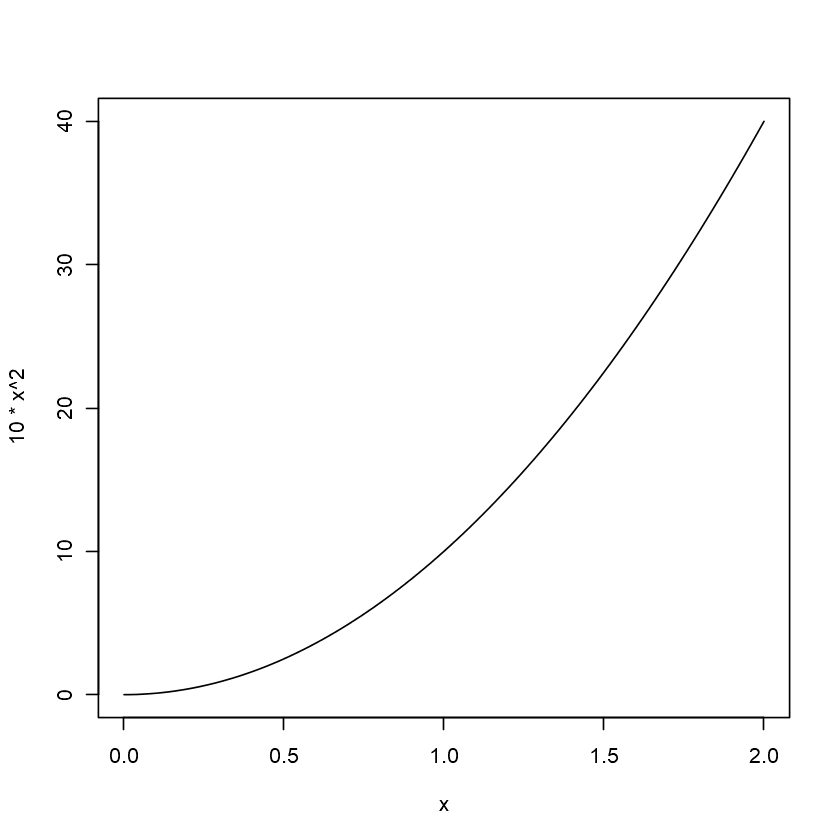

```r
# Plot a quick equation!
curve(10*x^2, from=0, to=2)
```

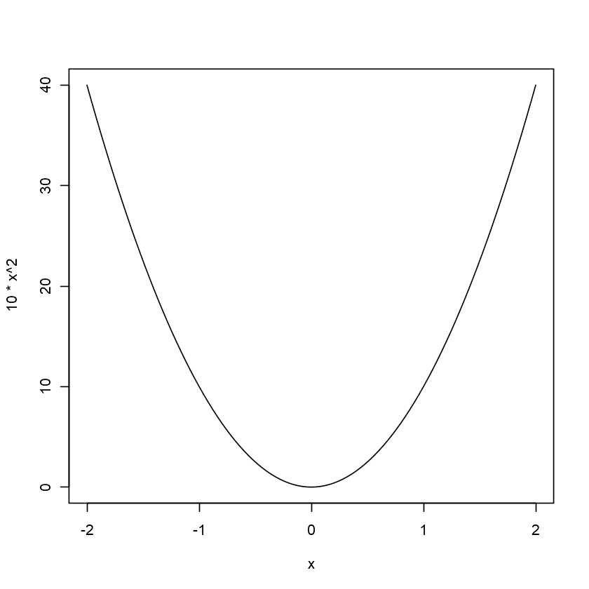

```r
# Plot a parabola
curve(10*x^2, xlim = c(-2,2))
```

## 2.2.0 Functions do the work for us

You may have noticed above that we did some crazy looking stuff involving parentheses `( )`. There are actually many functions for `( )` within R but this is all dependent upon context.

1. Most broadly we use `( )` to contain or separate actions and expressions. The development of R centres around a much older programming language but, in a nutshell, everything is evaluated from the innermost `( )` to the outermost set of `( )`.
2. A secondary purpose of `( )` is to indicate to R that you would like to activate a function by passing the contents of `( )` to the pre-existing function. This takes the form of

   `function_name(argument_1 = parameter_1, argument_2 = parameter_2, .., argument_n = parameter_n)`.

   or more simply

   `function_name(parameter_1, parameter_2, ..., parameter_n)` but parameter order in this case is quite important.

We'll talk about the structure of functions in more detail as the course progresses BUT know that

1. functions are used to perform common operations that may combine multiple actions or calculations.
2. functions are programmed or **defined** and they use **arguments** as a way to retrieve input or information to perform their jobs.
3. functions may or may not **return** a value upon their completion.

### 2.2.1 Use the `help()` function or `?` to learn more about functions

Often you may forget what the simple or complicated requirements of a function are but you can use `?` or `help(function_name)` to retrieve a description of a function which includes a description of the input arguments and output (if any) that is returned.

```r
# Use ? to retrieve a description of help()
?help
# Note the lack of ()?
# We don't want to invoke the function but rather just provide it's name!
```

| help {utils} | R Documentation |
| --- | --- |

Documentation

Description

`help` is the primary interface to the help systems.

Usage

```
help(topic, package = NULL, lib.loc = NULL,
     verbose = getOption("verbose"),
     try.all.packages = getOption("help.try.all.packages"),
     help_type = getOption("help_type"))
```

Arguments

[output not shown]

Details

The following types of help are available:

- Plain text help

- HTML help pages with hyperlinks to other topics, shown in a browser by `browseURL`.  
  (On Unix-alikes, where possible an existing browser window is re-used: the macOS GUI uses its own browser window.)

  If for some reason HTML help is unavailable (see `startDynamicHelp`), plain text help will be used instead.

- For `help` only, typeset as PDF – see the section on ‘Offline help’.

**On Unix-alikes:**

The ‘factory-fresh’ default is text help except from the macOS GUI, which uses HTML help displayed in its own browser window.

**On Windows:**

The default for the type of help is selected when **R** is installed – the ‘factory-fresh’ default is HTML help.

The rendering of text help will use directional quotes in suitable locales (UTF-8 and single-byte Windows locales): sometimes the fonts used do not support these quotes so this can be turned off by setting `options(useFancyQuotes = FALSE)`.

`topic` is not optional: if it is omitted **R** will give

- If a package is specified, (text or, in interactive use only, HTML) information on the package, including hints/links to suitable help topics.

- If `lib.loc` only is specified, a (text) list of available packages.

- Help on `help` itself if none of the first three arguments is specified.

Some topics need to be quoted (by backticks) or given as a character string. These include those which cannot syntactically appear on their own such as unary and binary operators, `function` and control-flow reserved words (including `if`, `else` `for`, `in`, `repeat`, `while`, `break` and `next`). The other `reserved` words can be used as if they were names, for example `TRUE`, `NA` and `Inf`.

If multiple help files matching `topic` are found, in interactive use a menu is presented for the user to choose one: in batch use the first on the search path is used. (For HTML help the menu will be an HTML page, otherwise a graphical menu if possible if `getOption("menu.graphics")` is true, the default.)

Note that HTML help does not make use of `lib.loc`: it will always look first in the loaded packages and then along `.libPaths()`.

Offline help

Typeset documentation is produced by running the LaTeX version of the help page through `pdflatex`: this will produce a PDF file.

The appearance of the output can be customized through a file ‘Rhelp.cfg’ somewhere in your LaTeX search path: this will be input as a LaTeX style file after `Rd.sty`. Some environment variables are consulted, notably R_PAPERSIZE (*via* `getOption("papersize")`) and R_RD4PDF (see ‘Making manuals’ in the ‘R Installation and Administration’ manual).

If there is a function `offline_help_helper` in the workspace or further down the search path it is used to do the typesetting, otherwise the function of that name in the `utils` namespace (to which the first paragraph applies). It should accept at least two arguments, the name of the LaTeX file to be typeset and the type (which is nowadays ignored). It accepts a third argument, `texinputs`, which will give the graphics path when the help document contains figures, and will otherwise not be supplied.

Note

Unless `lib.loc` is specified explicitly, the loaded packages are searched before those in the specified libraries. This ensures that if a library is loaded from a library not in the known library trees, then the help from the loaded library is used. If `lib.loc` is specified explicitly, the loaded packages are *not* searched.

If this search fails and argument `try.all.packages` is `TRUE` and neither `packages` nor `lib.loc` is specified, then all the packages in the known library trees are searched for help on `topic` and a list of (any) packages where help may be found is displayed (with hyperlinks for `help_type = "html"`). **NB:** searching all packages can be slow, especially the first time (caching of files by the OS can expedite subsequent searches dramatically).

References

Becker, R. A., Chambers, J. M. and Wilks, A. R. (1988) *The New S Language*. Wadsworth & Brooks/Cole.

See Also

`?` for shortcuts to help topics.

`help.search()` or `??` for finding help pages on a vague topic; `help.start()` which opens the HTML version of the **R** help pages; `library()` for listing available packages and the help objects they contain; `data()` for listing available data sets; `methods()`.

Use `prompt()` to get a prototype for writing `help` pages of your own package.

Examples

[output not shown]

[Package *utils* version 4.0.5 ]

```r
# Here we are using the () to define the function we want to know more about
help(help)
```

| help {utils} | R Documentation |
| --- | --- |

Documentation

Description

`help` is the primary interface to the help systems.

Usage

```
help(topic, package = NULL, lib.loc = NULL,
     verbose = getOption("verbose"),
     try.all.packages = getOption("help.try.all.packages"),
     help_type = getOption("help_type"))
```

Arguments

[output not shown]

Details

The following types of help are available:

- Plain text help

- HTML help pages with hyperlinks to other topics, shown in a browser by `browseURL`.  
  (On Unix-alikes, where possible an existing browser window is re-used: the macOS GUI uses its own browser window.)

  If for some reason HTML help is unavailable (see `startDynamicHelp`), plain text help will be used instead.

- For `help` only, typeset as PDF – see the section on ‘Offline help’.

**On Unix-alikes:**

The ‘factory-fresh’ default is text help except from the macOS GUI, which uses HTML help displayed in its own browser window.

**On Windows:**

The default for the type of help is selected when **R** is installed – the ‘factory-fresh’ default is HTML help.

The rendering of text help will use directional quotes in suitable locales (UTF-8 and single-byte Windows locales): sometimes the fonts used do not support these quotes so this can be turned off by setting `options(useFancyQuotes = FALSE)`.

`topic` is not optional: if it is omitted **R** will give

- If a package is specified, (text or, in interactive use only, HTML) information on the package, including hints/links to suitable help topics.

- If `lib.loc` only is specified, a (text) list of available packages.

- Help on `help` itself if none of the first three arguments is specified.

Some topics need to be quoted (by backticks) or given as a character string. These include those which cannot syntactically appear on their own such as unary and binary operators, `function` and control-flow reserved words (including `if`, `else` `for`, `in`, `repeat`, `while`, `break` and `next`). The other `reserved` words can be used as if they were names, for example `TRUE`, `NA` and `Inf`.

If multiple help files matching `topic` are found, in interactive use a menu is presented for the user to choose one: in batch use the first on the search path is used. (For HTML help the menu will be an HTML page, otherwise a graphical menu if possible if `getOption("menu.graphics")` is true, the default.)

Note that HTML help does not make use of `lib.loc`: it will always look first in the loaded packages and then along `.libPaths()`.

Offline help

Typeset documentation is produced by running the LaTeX version of the help page through `pdflatex`: this will produce a PDF file.

The appearance of the output can be customized through a file ‘Rhelp.cfg’ somewhere in your LaTeX search path: this will be input as a LaTeX style file after `Rd.sty`. Some environment variables are consulted, notably R_PAPERSIZE (*via* `getOption("papersize")`) and R_RD4PDF (see ‘Making manuals’ in the ‘R Installation and Administration’ manual).

If there is a function `offline_help_helper` in the workspace or further down the search path it is used to do the typesetting, otherwise the function of that name in the `utils` namespace (to which the first paragraph applies). It should accept at least two arguments, the name of the LaTeX file to be typeset and the type (which is nowadays ignored). It accepts a third argument, `texinputs`, which will give the graphics path when the help document contains figures, and will otherwise not be supplied.

Note

Unless `lib.loc` is specified explicitly, the loaded packages are searched before those in the specified libraries. This ensures that if a library is loaded from a library not in the known library trees, then the help from the loaded library is used. If `lib.loc` is specified explicitly, the loaded packages are *not* searched.

If this search fails and argument `try.all.packages` is `TRUE` and neither `packages` nor `lib.loc` is specified, then all the packages in the known library trees are searched for help on `topic` and a list of (any) packages where help may be found is displayed (with hyperlinks for `help_type = "html"`). **NB:** searching all packages can be slow, especially the first time (caching of files by the OS can expedite subsequent searches dramatically).

References

Becker, R. A., Chambers, J. M. and Wilks, A. R. (1988) *The New S Language*. Wadsworth & Brooks/Cole.

See Also

`?` for shortcuts to help topics.

`help.search()` or `??` for finding help pages on a vague topic; `help.start()` which opens the HTML version of the **R** help pages; `library()` for listing available packages and the help objects they contain; `data()` for listing available data sets; `methods()`.

Use `prompt()` to get a prototype for writing `help` pages of your own package.

Examples

[output not shown]

[Package *utils* version 4.0.5 ]

```r
# A list of common functions that we don't have time to explore
?str

# ?c
# ?seq
# ?setwd
# ?sort
# ?dir
# ?head
# ?names
# ?summary
# ?dim
# ?range
# ?max
# ?min
# ?sum
# ?pairs
# ?plot
```

| str {utils} | R Documentation |
| --- | --- |

Compactly Display the Structure of an Arbitrary R Object

Description

Compactly display the internal **str**ucture of an **R** object, a diagnostic function and an alternative to `summary` (and to some extent, `dput`). Ideally, only one line for each ‘basic’ structure is displayed. It is especially well suited to compactly display the (abbreviated) contents of (possibly nested) lists. The idea is to give reasonable output for **any** **R** object. It calls `args` for (non-primitive) function objects.

`strOptions()` is a convenience function for setting `options(str = .)`, see the examples.

Usage

[output not shown]

Arguments

[output not shown]

Value

`str` does not return anything, for efficiency reasons. The obvious side effect is output to the terminal.

Author(s)

Martin Maechler maechler@stat.math.ethz.ch since 1990.

See Also

`ls.str` for *listing* objects with their structure; `summary`, `args`.

Examples

[output not shown]

[output cut: 18 more lines]

[output not shown]

[Package *utils* version 4.0.5 ]

### 2.2.2 R evaluates functions by the order of parentheses

Remember back in section 2.2.0 we mentioned how R interprets brackets? When working or reading functions in R, it should be noted that functions are generally evaluated (or run) by the R interpreter from left to right and from inner-most parentheses to outer-most. This means you can indeed provide a function as a parameter to another function.

When writing code, it can quickly become complicated with inner functions like this:

`function_1(function_2(function_3())) + function_4()`

As we can see from above, `function_3()` must be evaluated first as it serves as a parameter to `function_2()`, which must itself be evaluated so it can be used as a paramater to `function_1()` before being added to `function_4()`. Imagine having multiple parts of these all happening in a single line of code? It can certainly hinder code readability down the road.

Of course there are [more complex function evaluations](https://stackoverflow.com/questions/23689211/precedence-of-a-function-call-in-r) but we won't really tread there in this course.

Furthermore, we will learn to remedy this kind of issue further down the road by writing our code in a way that flows more logically for readers. However, it is best to keep these ideas in mind when trying to read someone else's code.

**Section 2.0.0 Comprehension Question:** In what order will the functions in the following code be evaluated?

**function_2(function_4(function_3(), function_1()), function_5(function_6()))**

## Section 2.0.0 comprehension answer:

# 3.0.0 A [quick] intro to R's variables, data types, and data structures

## 3.1.0 Assigning variables

Up until now we've simply been calculating with R and the output appears after the code cell. There is nothing left behind in the R interpreter or memory. If we wanted to hold onto a number or calculation we would need to **assign** it to a named variable. In fact R has multiple methods for assigning a value to a variable and an order of precedence!

`->` and `->>` **Rightward assignment**: we won't really be using this in our course.

`<-` and `<<-` **Leftward assignment**: assignment used by most 'authentic' R programmers but really just a historical throwback.

`=` **Leftward assignment**: commonly used token for assignment in many other programming languages but carries dual meaning!

**Notes**

- assignment to a variable *does not* produce any output.
- R processes at each new line unless you use a semicolon (`;`) to separate commands
- In Jupyter, you can use `Alt` + `-` to produce the `<-` symbol

Let's try some exercises.

```r
# Assign with the standard =

a = 4

# Use the print command to print simple and complex expressions
print(a)

# Or just evaluate the expression to standard output
a + 2
```

```
[1] 4
```

6

```r
#Left hand assigner (original way to assign results)
# sometimes the <- is necessary for functions originally created in S.
# Often seen on R help forums if you Google future issues

a <- 3
a
```

3

```r
#Right hand assigner

3 -> d
d
```

3

```r
# Assign some variables
a = 4
b = 2

# Multiply them
a * b
```

8

```r
# each code after a semicolon is interpreted as a new line
a=4 ; b=2; a*b
```

8

### 3.1.1 Blank spaces are usually ignored by the interpreter

White space is used to separate between commands and variables as the code is run but the **total** number of spaces is irrelevant to the interpreter when it is running your code.

Let's see it in action

```r
b <- 2

a<-3;b*a

# versus

a = 3; b *    a
```

6

6

A more complex example

for (i in unique(raw_area_long$date)){sub.dat<-subset(raw_area_long, raw_area_long$date==i) umoles<-(((sub.dat$area[sub.dat$date==i]-calib_coeff$intercept[calib_coeff$date==i])/calib_coeff$slope[calib_coeff$date==i])/1000)*sub.dat$headspace_mL[sub.dat$date==i]}

Using spaces to organize the above code, we can clarify what's happening! Notice we even use indentation to help sort out the **flow** of our code. We'll talk more about that in detail in lecture 07.

for (i in unique(raw_area_long$date)) { sub.dat <- subset (raw_area_long, raw_area_long$date == i) umoles <- ( ( ( sub.dat$area[sub.dat$date == i] - calib_coeff$intercept [calib_coeff$date == i] ) / calib_coeff$slope [ calib_coeff$date == i] ) / 1000 ) * sub.dat$headspace_mL }

### 3.1.1.1 A special case where blankspace can change interpretation

Due to the nature of how the R-kernel **interprets** the order/context of symbols, and how symbols can be combined, we must address the importance of `<-` versus `< -`.

- The former case `<-` is our symbol for leftward assignment
- The latter case breaks our symbol into two parts to create an *expression* (more on that in section **3.2.0**)

```r
# Assignment
a <- 3

# Evalution
a < -3

# Evalution with extra space!
a < -     3
```

FALSE

FALSE

### 3.1.1.2 A case where blankspace amounts matter

Under some special circumstances, spaces are required, e.g. when using function `paste()` and its argument `sep = ' '`.

```r
# No spaces
paste("Can", "I", "go", "out", "now", "?", sep = "")

# Single space as a separator
paste("Can", "I", "go", "out", "now", "?", sep = " ")

# Triple space as a separator
paste("Can", "I", "go", "out", "now", "?", sep = "   ")
```

'CanIgooutnow?'

'Can I go out now ?'

'Can I go out now ?'

### 3.1.2 R calculates from the right side first before (leftward) assignment

R calculates the right side of the assignment **first** and the result is then applied to the left. This is a common paradigm in programming that simplifies variable behaviours for counting and tracking results as they build up over time.

This also allows us to increment variables or manipulate objects to update them!

```r
# What will be the final value of i?

i = 1
i = i + 1
i = i + 1
i = i + 1
i = i + 1
i = i + 1
i
```

6

This behaviour can be extended in a more complex fashion to encompass multiple variables

**Remember!** Variables are specific identifiers/placeholders that allow us to *access* our data. We can **change** the nature and size of that data simply by reassigning the value of the variable.

```r
# Remind ourselves the values of a and b
a;b
# Use multiple values in an expression assigned to a variable
result <- 5 * a + 2 * b
result

# make a calculation
result ^ pi
```

3

2

19

10406.936832354

```r
# Use and overwrite the current value of "result"
result <- result ^ pi

# this PERMANENTLY overwrote your old 'result' object. If this is an important value be sure to keep it safe!
result
```

10406.936832354

**Caution!** Variable names are case-sensitive. When assigning variables, remember to use original, descriptive names to reduce errors in your code. You can use the *Tab* key to help autocomplete your code. Walk the fine balance between **descriptive** and *overly long* variable names.

```r
# Don't forget that variable names ARE case-sensitive
a = 5
A = 7
b = 3
B = 15

# Output our variable values
b; B; a; A; a+A;
```

3

15

5

7

12

## 3.2.0 Data types are the basic building blocks of R

Data types are used to classify the basic spectrum of values that are used in R. Here's a table describing *some* of the common data types we'll encounter.

| Data type | Description | Example |
| --- | --- | --- |
| character | Can be single or multiple characters (strings) of letters and symbols. Assigned using double `'` or `"` | a#c&E |
| integer | Whole number values, either positive or negative | 1 |
| double | Any number that is not an integer, AKA *numeric* | 7.5 |
| logical | Also known as a boolean, representing the state of a conditional (question) | TRUE or FALSE |
| NA | Represents the value of "Not Available" usually seen when imported data has missing values | NA |

### 3.2.1 Data structures hold single or multiple values

The job of data structures is to "host" the different data types. There are five basic types of data structures that we may encounter while using R:

| Data structure | Dimensions | Restrictions |
| --- | --- | --- |
| vector | 1D | Holds a single data type |
| matrix | 2D | Holds a single data type |
| array | nD | Holds a single data type |
| data frame | 2D | Holds multiple data types with some restrictions |
| list | 1D (technically) | Holds multiple data types AND structures |

[figure not shown]

### 3.2.2 Scalars - *"One is the loneliest data type"*

One single value from any of the above data types. It is the smallest possible "unit" of data within R.

```r
# It doesn't matter what your variable is named, a scalar is still a single value
X <- 5
b <- 10
```

### 3.2.3 Vectors are like a queue of a single data type

There is a numerical order to a vector, much like a queue AND you can access each element (piece of data) individually or in groups.

Here are what vectors of each data 'type' would look like.

**Note:** character items must be in a set of either single **or** double quotations. An 'L' is placed next to a number to specify it as an integer rather than a double. You may decided to use this notation in order to specifically save on memory as integers use less than doubles!

```r
# character vectors
character_vector <- c('bacteria', 'virus', "archaea")
character_vector
```

1. 'bacteria'

2. 'virus'

3. 'archaea'

```r
# numeric vectors
numeric_vector <- c(1:10) # The colon specifies an inclusive range of values
numeric_vector
```

1. 1

2. 2

3. 3

4. 4

5. 5

6. 6

7. 7

8. 8

9. 9

10. 10

```r
# logical vectors
logical_vector <- c(TRUE, FALSE, TRUE) # TRUE and FALSE are also know as "boolean" values
logical_vector
```

1. TRUE

2. FALSE

3. TRUE

```r
# Integer vectors
integer_vector <- c(1L, 8L)
# The "L" makes the numbers integers. Can be used to get your code to run faster and consume less memory.
# A double ("numeric") vector uses 8 bytes per element. An integer vector uses only 4 bytes per element

integer_vector
```

1. 1

2. 8

```r
# What happens if we try to include more than one type of data?
mixed_vector <- c("bacteria", 1, TRUE, NA)
mixed_vector

# Let's look at the structure of our vector
str(mixed_vector)
```

1. 'bacteria'

2. '1'

3. 'TRUE'

4. NA

```
 chr [1:4] "bacteria" "1" "TRUE" NA
```

### 3.2.3.1 Coercion changes data from one type to another (if possible)

R will *coerce* (force) your vector to be of one data type, in this case the type that is most inclusive is a character vector. When we explicitly force a change from one data type to the next, it is known as **conversion** or **casting**.

```r
# Let's convert our mixed_vector
into_numeric <- as.numeric(mixed_vector); into_numeric

# What about our logical_vector?
as.numeric(logical_vector)
```

1. <NA>

2. 1

3. <NA>

4. <NA>

1. 1

2. 0

3. 1

### 3.2.3.2 What happened to our data??

Let's highlight the unexpected result from above for a couple of reasons:

1. Keep your data types in mind. It is good practice to look at your object or the global environment to make sure the object that you just made is what you think it is.
2. It can be useful for data analysis to be able to switch from TRUE/FALSE to 1/0, and it is pretty easy, as we have just seen.

**Learn more about data-type coercion:** If you're interested in learning the order of operations for coercion, you can find more information on how R handles it in [R in a nutshell](https://www.oreilly.com/library/view/r-in-a/9781449358204/ch05s08.html)

### 3.2.3.3 Vector contents can be individually named using the `name()` function

Within a vector, each individual element can be assigned to a character-based name. This can act as a way to locate values based on what they represent and not by their position within the vector.

```r
names(logical_vector) <- c("male", "elderly", "heart attack")
logical_vector
```

**male**

TRUE

**elderly**

FALSE

**heart attack**

TRUE

```r
#is equivalent to

logical_vector <- c("male" = TRUE, "elderly" = FALSE, "heart attack" = TRUE)

logical_vector
```

**male**

TRUE

**elderly**

FALSE

**heart attack**

TRUE

```r
# or using a ;

logical_vector <- c("male" = TRUE, "elderly" = FALSE, "heart attack" = TRUE); logical_vector
```

**male**

TRUE

**elderly**

FALSE

**heart attack**

TRUE

### 3.2.3.4 Use `length()` to identify the number of elements in a vector

Remember that a vector is a container for your data which you can think of as a queue of boxes where each box contains a value. We can retrieve the length of this queue using the `length()` function. We'll learn additional functions later that we can apply broadly to retrieve information about various objects.

```r
# The number of elements in a vector is its length.
length(character_vector)

length(numeric_vector)

length(logical_vector)
```

3

10

3

### 3.2.3.5 Use the `[ ]` indexing notation to extract values

For most data structures in R, you can use index notation to extract values from the object. To accomplish this, use the square brackets `[ ]`, separating dimensions using a comma (`,`). You can create indices using:

- Positive integers
- Negative integers
- Zero
- Blank spaces
- Logical values
- Names

These indices can be supplied singly, as a vector with `c()`, or a range with `start:end`. Note, however, that you cannot *mix* positive and negative values! Throughout the course, we may also refer to the act of **indexing** portions of a data structure as **slicing**.

**Watch out!** Indexing in R follows real-world arithmetic notation where vectors are represented as n-tuples indexed from 1 to n. This might be unfamiliar if you're coming from a 0-indexed system like C++, Java, or Python.

```r
# Display our character vector again
character_vector

# You can grab a specific element by its index
character_vector[3]
```

1. 'bacteria'

2. 'virus'

3. 'archaea'

'archaea'

```r
# Use the ":" to generate a range of indices automatically as a vector

1:10 # All positive values

-5:0 # Negative values to 0

-5:5 # A range spanning across negative to positive values
```

1. 1

2. 2

3. 3

4. 4

5. 5

6. 6

7. 7

8. 8

9. 9

10. 10

1. -5

2. -4

3. -3

4. -2

5. -1

6. 0

1. -5

2. -4

3. -3

4. -2

5. -1

6. 0

7. 1

8. 2

9. 3

10. 4

11. 5

```r
#second and third element in the vector inclusive (varies across programming languages)
character_vector[2:3]
```

1. 'virus'

2. 'archaea'

```r
#you can use negative indexing to select 'everything but'
character_vector[-2]

character_vector[-c(2,3)]
```

1. 'bacteria'

2. 'archaea'

'bacteria'

```r
# You can't mix negative and positive values!
character_vector[c(-1, 2)]
```

```
Error in character_vector[c(-1, 2)]: only 0's may be mixed with negative subscripts
Traceback:
```

```r
# You can grab elements by their assigned "names"
logical_vector["male"]

logical_vector[c("male", "elderly")]
```

**male:** TRUE

**male**

TRUE

**elderly**

FALSE

**Section 3.2.3 Comprehension Question:** Look at the following code. What do you expect the result to be when you run it? Why/How do you think this happens? **Hint:** think again about how sequences of numbers are generated above using the **[start:end]** notation.

```r
# Comprehension Question 3.2.3
compQ <- c(2:11); compQ

compQ[-5:0]
```

## Section 3.2.3 comprehension answer:

### 3.2.4 Matrices are 2-dimensional containers of a single data type

Thus matrices are like a 2D version of vectors. They can be accessed similarly to vectors but in a `[row,column]` format

### 3.2.4.1 A reminder about functions inside functions

Recall that in R, functions within functions are read inside-out, i.e. moving from the inner most parenthesis and outwards:

`matrix(c(rep(0, 10), rep(1,10)), nrow = 5, ncol = 5)`

Here the two `rep(...)` functions will be evaluated before evaluating `matrix(...)`

Note that the `rep(value, times)` function produces a vector by **repeating** the parameter `value` by the specified parameter `times`.

```r
# What will the output be?
# Note that each "parameter" has been separated to its own line
my_matrix <- matrix(c(rep(0, 10), rep(1, 10)),
                    nrow = 5,
                    ncol = 5)

my_matrix
```

A matrix: 5 × 5 of type dbl

| 0 | 0 | 1 | 1 | 0 |
| --- | --- | --- | --- | --- |
| 0 | 0 | 1 | 1 | 0 |
| 0 | 0 | 1 | 1 | 0 |
| 0 | 0 | 1 | 1 | 0 |
| 0 | 0 | 1 | 1 | 0 |

```r
# Equivalent result by calling rep just once

my_matrix <- matrix(c(rep(0:1, each = 10)),
                    nrow = 5,
                    ncol = 5)

my_matrix
```

A matrix: 5 × 5 of type int

| 0 | 0 | 1 | 1 | 0 |
| --- | --- | --- | --- | --- |
| 0 | 0 | 1 | 1 | 0 |
| 0 | 0 | 1 | 1 | 0 |
| 0 | 0 | 1 | 1 | 0 |
| 0 | 0 | 1 | 1 | 0 |

### 3.2.4.2 Vector recycling occurs on some element-wise operations

How would I make this same matrix from above without vector recycling as part of the `matrix()` function? Can you think of 2 ways?

```r
# Make a matrix by recycling within rep() but not within the matrix() call
my_matrix <- matrix(c(rep(0:1,
                          each = 10,
                          times = 2,
                          length = 25)),
                    nrow = 5,
                    ncol = 5)

# print the matrix
my_matrix; print("version 1")
```

A matrix: 5 × 5 of type int

| 0 | 0 | 1 | 1 | 0 |
| --- | --- | --- | --- | --- |
| 0 | 0 | 1 | 1 | 0 |
| 0 | 0 | 1 | 1 | 0 |
| 0 | 0 | 1 | 1 | 0 |
| 0 | 0 | 1 | 1 | 0 |

```
[1] "version 1"
```

```r
# No recycling in generating the initial vector
my_matrix <- matrix(c(rep(0, 10), rep(1,10), rep(0, 5)), nrow = 5, ncol = 5)
my_matrix; print("version 2")
```

A matrix: 5 × 5 of type dbl

| 0 | 0 | 1 | 1 | 0 |
| --- | --- | --- | --- | --- |
| 0 | 0 | 1 | 1 | 0 |
| 0 | 0 | 1 | 1 | 0 |
| 0 | 0 | 1 | 1 | 0 |
| 0 | 0 | 1 | 1 | 0 |

```
[1] "version 2"
```

```r
# Just write out the entire vector you want to convert to matrix
my_matrix <- matrix(c(0,0,0,0,0,0,0,0,0,0,1,1,1,1,1,1,1,1,1,1,0,0,0,0,0), nrow = 5, ncol = 5)
my_matrix; print("version 3")
```

A matrix: 5 × 5 of type dbl

| 0 | 0 | 1 | 1 | 0 |
| --- | --- | --- | --- | --- |
| 0 | 0 | 1 | 1 | 0 |
| 0 | 0 | 1 | 1 | 0 |
| 0 | 0 | 1 | 1 | 0 |
| 0 | 0 | 1 | 1 | 0 |

```
[1] "version 3"
```

```r
# We can replicate through coercion!
my_matrix <- matrix(as.numeric(c(rep(FALSE, 10), rep(TRUE,10), rep(FALSE, 5))), nrow = 5, ncol = 5)
my_matrix; print("version 4")
```

A matrix: 5 × 5 of type dbl

| 0 | 0 | 1 | 1 | 0 |
| --- | --- | --- | --- | --- |
| 0 | 0 | 1 | 1 | 0 |
| 0 | 0 | 1 | 1 | 0 |
| 0 | 0 | 1 | 1 | 0 |
| 0 | 0 | 1 | 1 | 0 |

```
[1] "version 4"
```

```r
#This may be a good time to mention that TRUE and FALSE can be abbreviated to T and F
my_matrix <- matrix(as.numeric(c(F,F,F,F,F,F,F,F,F,F,T,T,T,T,T,T,T,T,T,T,F,F,F,F,F)), nrow = 5, ncol = 5)
my_matrix; print("version 5")
```

A matrix: 5 × 5 of type dbl

| 0 | 0 | 1 | 1 | 0 |
| --- | --- | --- | --- | --- |
| 0 | 0 | 1 | 1 | 0 |
| 0 | 0 | 1 | 1 | 0 |
| 0 | 0 | 1 | 1 | 0 |
| 0 | 0 | 1 | 1 | 0 |

```
[1] "version 5"
```

**Notice how the matrices are populated one column at a time?**

*Challenge: What do you think this matrix will look like?*

`my_matrix <- matrix(c(0,0,0,1,1,1,0,0,0,0,1,1,1,1,0,0,0,0,1,1,1,1,1,1,0), nrow = 5, ncol = 5)`

```r
matrix(c(0,0,0,1,1,1,0,0,0,0,1,1,1,1,0,0,0,0,1,1,1,1,1,1,0), nrow = 5, ncol = 5)
```

A matrix: 5 × 5 of type dbl

| 0 | 1 | 1 | 0 | 1 |
| --- | --- | --- | --- | --- |
| 0 | 0 | 1 | 0 | 1 |
| 0 | 0 | 1 | 0 | 1 |
| 1 | 0 | 1 | 1 | 1 |
| 1 | 0 | 0 | 1 | 0 |

### 3.2.4.3 Bracket and parentheses location matters!

Remember that each call to a function whether it is `c()`, `rep()`, `matrix()`, etc., uses parentheses to define the start and end of parameters that are being supplied. Some of the hardest-to-find errors in our code involves the misplacement or incorrect pairings of `()` in multi-layered functions.

```r
matrix(c(rep(0, 10), rep(1,10), nrow = 5, ncol = 5))
```

A matrix: 22 × 1 of type dbl

| 0 |
| --- |
| 0 |
| 0 |
| 0 |
| 0 |
| 0 |
| 0 |
| 0 |
| 0 |
| 0 |
| 1 |
| 1 |
| 1 |
| 1 |
| 1 |
| 1 |
| 1 |
| 1 |
| 1 |
| 1 |
| 5 |
| 5 |

**What happened above?**

R code is evaluated inside-out but the brackets here are poorly positioned. With the command above you end up with a single column matrix of numbers equivalent to c(0x10, 1x10, 5, 5).

**Remember** to be mindful of your bracket placement or you'll be in for some headaches!